# IODS-Final

Maria Karolina Wickholm

- Author: Maria Karolina Wickholm
- GitHub repository: https://github.com/kkarolinaw/IODS-final
- Final assignment web: https://kkarolinaw.github.io/IODS-final/indexF.html
- E-mail: maria.wickholm@helsinki.fi

# “IODS-Final”

**About this project** *In the final assignment, I’ll be trying to look deeper in the human data introduced on IODS course.

Interest in variables “GNI” = Gross National Income per capita and “Edu.Exp” = Expected years of schooling and their effect on “Life.Exp” = Life expectancy at birth.

Research question: Which of the following variables, GNI or EDU.Exp have a bigger impact on life expectancy?

Hypothesis: Division between LDCs (less developed countries) DCs (developed countries), so that variable GNI is probably more relevant in LDCs, whereas Edu.Exp effect more DCs.

GitHub repository: https://github.com/kkarolinaw/IODS-final Final assignment web: https://kkarolinaw.github.io/IODS-final/indexF.html ***

# Data loading and introduction

load the data “human”

```r
human<- read.table("http://s3.amazonaws.com/assets.datacamp.com/production/course_2218/datasets/human1.txt", sep=",", header = T)
dim(human)
```

```
## [1] 195  19
```

```r
summary(human)
```

```
##     HDI.Rank                     Country         HDI
##  Min.   :  1.00   Afghanistan        :  1   Min.   :0.3480
##  1st Qu.: 47.75   Albania            :  1   1st Qu.:0.5770
##  Median : 94.00   Algeria            :  1   Median :0.7210
##  Mean   : 94.31   Andorra            :  1   Mean   :0.6918
##  3rd Qu.:141.25   Angola             :  1   3rd Qu.:0.8000
##  Max.   :188.00   Antigua and Barbuda:  1   Max.   :0.9440
##  NA's   :7        (Other)            :189
##     Life.Exp        Edu.Exp         Edu.Mean           GNI
##  Min.   :49.00   Min.   : 4.10   Min.   : 1.400   2,803  :  2
##  1st Qu.:65.75   1st Qu.:11.10   1st Qu.: 5.550   1,096  :  1
##  Median :73.10   Median :13.10   Median : 8.400   1,123  :  1
##  Mean   :71.07   Mean   :12.86   Mean   : 8.079   1,130  :  1
##  3rd Qu.:76.80   3rd Qu.:14.90   3rd Qu.:10.600   1,228  :  1
##  Max.   :84.00   Max.   :20.20   Max.   :13.100   1,328  :  1
##                                                   (Other):188
##  GNI.Minus.Rank        GII.Rank           GII            Mat.Mor
##  Min.   :-84.0000   Min.   :  1.00   Min.   :0.0160   Min.   :   1.0
##  1st Qu.: -9.0000   1st Qu.: 47.75   1st Qu.:0.2030   1st Qu.:  16.0
##  Median :  1.5000   Median : 94.00   Median :0.3935   Median :  69.0
##  Mean   :  0.1862   Mean   : 94.31   Mean   :0.3695   Mean   : 163.2
##  3rd Qu.: 11.0000   3rd Qu.:141.25   3rd Qu.:0.5272   3rd Qu.: 230.0
##  Max.   : 47.0000   Max.   :188.00   Max.   :0.7440   Max.   :1100.0
##  NA's   :7          NA's   :7        NA's   :33       NA's   :10
##    Ado.Birth         Parli.F          Edu2.F          Edu2.M
##  Min.   :  0.60   Min.   : 0.00   Min.   :  0.9   Min.   :  3.20
##  1st Qu.: 15.45   1st Qu.:12.47   1st Qu.: 27.8   1st Qu.: 38.30
##  Median : 40.95   Median :19.50   Median : 55.7   Median : 60.00
##  Mean   : 49.55   Mean   :20.60   Mean   : 54.8   Mean   : 60.29
##  3rd Qu.: 71.78   3rd Qu.:27.02   3rd Qu.: 81.8   3rd Qu.: 85.80
##  Max.   :204.80   Max.   :57.50   Max.   :100.0   Max.   :100.00
##  NA's   :5        NA's   :3       NA's   :26      NA's   :26
##      Labo.F          Labo.M         Edu2.FM          Labo.FM
##  Min.   :13.50   Min.   :44.20   Min.   :0.1717   Min.   :0.1857
##  1st Qu.:44.50   1st Qu.:68.88   1st Qu.:0.7284   1st Qu.:0.5987
##  Median :53.30   Median :75.55   Median :0.9349   Median :0.7514
##  Mean   :52.61   Mean   :74.74   Mean   :0.8541   Mean   :0.7038
##  3rd Qu.:62.62   3rd Qu.:80.15   3rd Qu.:0.9968   3rd Qu.:0.8513
##  Max.   :88.10   Max.   :95.50   Max.   :1.4967   Max.   :1.0380
##  NA's   :11      NA's   :11      NA's   :26       NA's   :11
```

The Human data has 195 observations and 19 variables Description of the data set Origin of the data: http://hdr.undp.org/en/content/human-development-index-hdi

The data used in this analysis consists of various development indicators in several countries and is provided by United Nations Development programme. The data consists of integer, character and numerical variables, where character=country, int=HDI_rank, GNI_HDI_rank. GII_rank and MatMort. Rest of the data frame are numerical.

Below are the column names and their full meanings

“Country” = Country name, “HDI.Rank” = Human development index, “GNI” = Gross National Income per capita, “Life.Exp” = Life expectancy at birth, “Edu.Exp” = Expected years of schooling, “Mat.Mor” = Maternal mortality ratio, “Ado.Birth” = Adolescent birth rate, “GII” = Gender Inequality Index, “Ado.Birth” = Adolescent birth rate, “Parli.F” = Shared of seats in parliament held by women, “Edu2.F” = Population with at least some secondary education, women, “Edu2.M” = Population with at least some secondary education, men, “Labo.F”= Labour force participation rate, women, “Labo.M” = Labour force participation rate, men, “Edu2.FM”= Population with at least some secondary education combined, “Labo.FM” = Labour force participation rate combined

# Data wrangling and hypothesis

The following analyse is inspired by Wilkinson and Pickett (2010) and their notification on how raising the living standards by continuous economic growth, is still relevant in Less developed countries. They however point out that the same effect differs in developed countries, at some point the correlation between economic growth and raining living standards looses its importance. To test this hypothesis, I’m going to keep only some variables from the human data. Variables of interest are Life expectancy at birth, Gross National Income per capita, Expected years of schooling and Human developmen index ranking. Shortly, I’m taking a look how GNI and Edu.Exp will effect on Life expecancy.

First, lets access some libraries

```r
library(dplyr)
library(tidyverse)
```

```r
library(corrplot)
library(GGally)
library(ggplot2)
```

```r
human$GNI <- str_replace(human$GNI, pattern=",", replace ="") %>% as.numeric
```

```r
str(human$GNI)
```

```
##  num [1:195] 64992 42261 56431 44025 45435 ...
```

```r
keep <- c("Country", "Life.Exp", "Edu.Exp", "GNI", "HDI.Rank")
```

```r
library("dplyr")
human <- select(human, one_of(keep))
data.frame(human[-1], comp = complete.cases(human))
```

[output not shown]

[output cut: 181 more lines]

```r
human_ <- filter(human, complete.cases(human))
```

Now the data has only the variables needed for the analyse.

Next, the observations which relate to regions instead of countries are removed.

```r
last <- nrow(human_) - 7
human_ <- human_[1:last,]
```

```r
rownames(human_) <- human_$Country
human_ <- human_
```

```r
colnames(human_)
```

```
## [1] "Country"  "Life.Exp" "Edu.Exp"  "GNI"      "HDI.Rank"
```

Just in case if I get a flow on and maybe want later on look at the data with high and low HDI rankings: divide data set human to countries with high HDI.Rank and low HDI.Rank. I will also take a look at the variable characters and plot two scatter plots of the variables at interest.

```r
human_$HDI.Rank <- str_replace(human_$HDI.Rank, pattern=",", replace ="") %>% as.numeric
str(human_$HDI.Rank)
```

```
##  num [1:181] 1 2 3 4 5 6 6 8 9 9 ...
```

```r
LDC <- filter(human_, HDI.Rank > 95)
DC <- filter(human_, HDI.Rank < 95)
Life.Exp <- human_$Life.Exp
Edu.Exp <- human_$Edu.Exp
GNI <- human_$GNI
HDI.Rank <- human_$HDI.Rank
human_$Life.Exp
```

```
##   [1] 81.6 82.4 83.0 80.2 81.6 80.9 80.9 79.1 82.0 81.8 83.0 84.0 80.0 82.2
##  [15] 80.7 82.6 81.9 82.4 81.7 83.5 80.8 82.2 81.4 80.8 80.4 82.6 83.1 78.6
##  [29] 80.9 76.8 78.8 80.2 78.2 81.3 76.3 77.4 73.3 80.6 74.3 76.3 77.0 81.7
##  [43] 80.9 75.2 76.6 74.2 77.3 74.4 76.2 71.3 70.1 76.8 74.7 77.2 75.4 69.4
##  [57] 75.6 76.1 74.2 72.7 77.6 74.7 74.4 73.1 70.4 74.9 79.4 79.3 79.4 75.4
##  [71] 74.2 75.3 74.9 76.8 74.5 74.9 73.8 70.8 73.4 74.0 75.4 71.0 74.8 74.6
##  [85] 77.8 74.7 76.5 75.9 75.1 75.8 70.0 69.4 74.4 77.8 71.6 74.8 74.0 72.9
##  [99] 75.7 72.8 70.0 73.5 71.1 76.8 73.4 64.5 71.6 71.1 65.6 64.4 68.9 72.9
## [113] 72.9 68.4 68.2 73.0 57.4 75.8 68.3 70.6 69.4 73.3 69.1 66.4 74.9 74.0
## [127] 64.8 71.8 69.4 68.0 73.1 69.5 68.2 69.6 71.9 62.3 66.0 57.6 60.1 61.4
## [141] 66.2 71.6 68.4 66.5 61.6 69.6 66.2 65.9 52.3 49.0 65.0 52.8 55.5 65.1
## [155] 57.5 63.1 67.9 62.6 63.3 63.8 49.8 59.7 62.8 64.2 58.5 59.6 63.5 62.0
## [169] 55.7 66.5 60.4 51.5 62.8 64.1 60.2 58.7 60.9 55.2 58.0 55.1 50.9
```

```r
human_$Edu.Exp
```

```
##   [1] 17.5 20.2 15.8 18.7 17.9 16.5 18.6 16.5 15.9 19.2 15.4 15.6 15.0 15.8
##  [15] 16.2 19.0 16.9 16.0 13.9 15.3 16.3 16.0 15.7 17.1 16.8 17.3 16.0 16.4
##  [29] 17.6 16.5 14.5 14.0 13.8 13.5 15.1 15.5 16.4 14.4 16.3 17.9 13.3 15.2
##  [43] 16.3 15.4 14.4 15.2 14.8 14.7 15.2 15.7 14.7 13.6 14.2 15.5 12.6 15.0
##  [57] 15.4 14.0 14.4 13.7 13.3 12.7 15.6 13.4 12.3 14.4 13.8 13.8 13.9 15.1
##  [71] 14.2 14.5 13.7 13.1 15.2 13.8 12.9 11.9 15.8 13.5 13.4 15.1 14.0 13.1
##  [85] 11.8 12.3 13.6 14.2 12.6 13.1 15.7 14.6 13.5 12.7 14.0 14.6 13.5 13.4
##  [99] 12.4 14.7 13.6 13.1 12.7 13.0 12.9 12.5 11.9 13.5 10.8 12.5 13.0 11.9
## [113] 13.0 11.5 11.3 12.3 13.6 11.9 13.2 12.5 10.1 13.5 11.7 10.3 11.5 11.6
## [127] 11.3 10.7 11.2 11.7 11.1 12.6 11.7 12.3 10.6 11.1 12.3  9.0 13.5 11.5
## [141] 10.6 10.0 10.9 11.3 11.0 12.4  7.8  8.6 11.4 11.3  9.2  9.0 10.4 10.3
## [155] 10.9  8.5  9.2  9.9 11.5  9.2 11.1 12.2  8.7 10.3  9.8 11.1  7.0  6.4
## [169]  7.6  7.9  9.3  8.9 10.8  8.5  8.8  9.8  9.5  9.0  8.4  9.3  8.6
```

```r
human_$GNI
```

```
##   [1]  64992  42261  56431  44025  45435  43919  39568  52947  42155  32689
##  [11]  76628  53959  79851  45636  39267  35182  33890  30676  58711  36927
##  [21]  41187  38056  43869  38695  27852  32045  33030  26660  24524  25214
##  [31]  72570  28633 123124  43978  25845  23177  24500  27930  52821  22050
##  [41]  60868  21290  25757  22916  38599  22281  19409  83961  14558  16676
##  [51]  22352  34858  18108  19283  21336  20867  12488  20070  15596  13496
##  [61]  18192  22762  17470  23300  26090  12190   7301  16509  13413  15440
##  [71]  16159  18677   9779  16056  15175   7164  20805  16428  10939  11365
##  [81]  11780   8178  13054  11015   9943   8124   9638  10605   9765  12547
##  [91]   7493  10729  13323   9994  14911  10404  12040   9937   7415   5069
## [101]   7614  11883  15617  12328   5327  16646   5223  10512  13066  16367
## [111]   9788   7643   4699   5567   7915   7349  12122   5092   5760   3044
## [121]  14003   6094   3432   6522   4457   6850   9418   6929   2517   5497
## [131]   3938   7176   5363   2728   2803   6012   2434  21056   3734   3852
## [141]   4680   3191   2949   2918   2762   2311   4866   4608   6822   5542
## [151]   2411   5341   2803   1328   1615   3560   1540   2463   1456   3519
## [161]   3306   1228   1669   1458   1613   1767   3809   3276   2332   2188
## [171]   1885   3171    747   1428   1507    680    805   1362   1583   1123
## [181]   1780
```

```r
human_$HDI.Rank
```

```
##   [1]   1   2   3   4   5   6   6   8   9   9  11  12  13  14  14  16  17
##  [18]  18  19  20  21  22  23  24  25  26  27  28  29  30  31  32  32  34
##  [35]  35  36  37  37  39  40  41  42  43  44  45  46  47  48  49  50  50
##  [52]  52  52  52  55  56  57  58  59  60  60  62  63  64  64  66  67  67
##  [69]  69  69  71  72  73  74  75  76  77  78  79  80  81  81  83  84  85
##  [86]  85  85  88  89  90  90  90  93  94  94  96  97  97  99 100 101 101
## [103] 103 104 105 106 107 108 109 110 110 112 113 114 115 116 116 116 119
## [120] 120 121 122 123 124 125 126 126 128 129 130 131 132 133 134 134 136
## [137] 137 138 139 140 141 142 143 143 145 145 147 148 149 150 151 152 153
## [154] 154 155 156 156 158 159 160 161 162 163 163 163 166 167 168 169 170
## [171] 171 172 173 174 175 176 177 178 179 180 181
```

# Linear regression & analyse

Linear regression is a linear approach on modeling relationships between variables. It consists of a dependant variable y and an explanatory variable x. In this section I’m contributing the variables GNI and Edu.Exp to Life expectancy with linear regression.

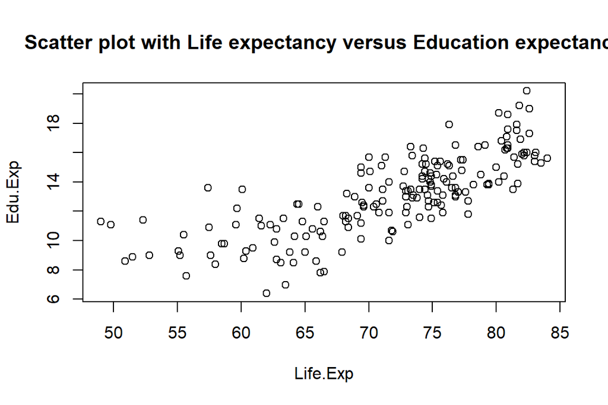

```r
plot(Life.Exp, Edu.Exp, main = title <- "Scatter plot with Life expectancy versus Education expectancy")
```

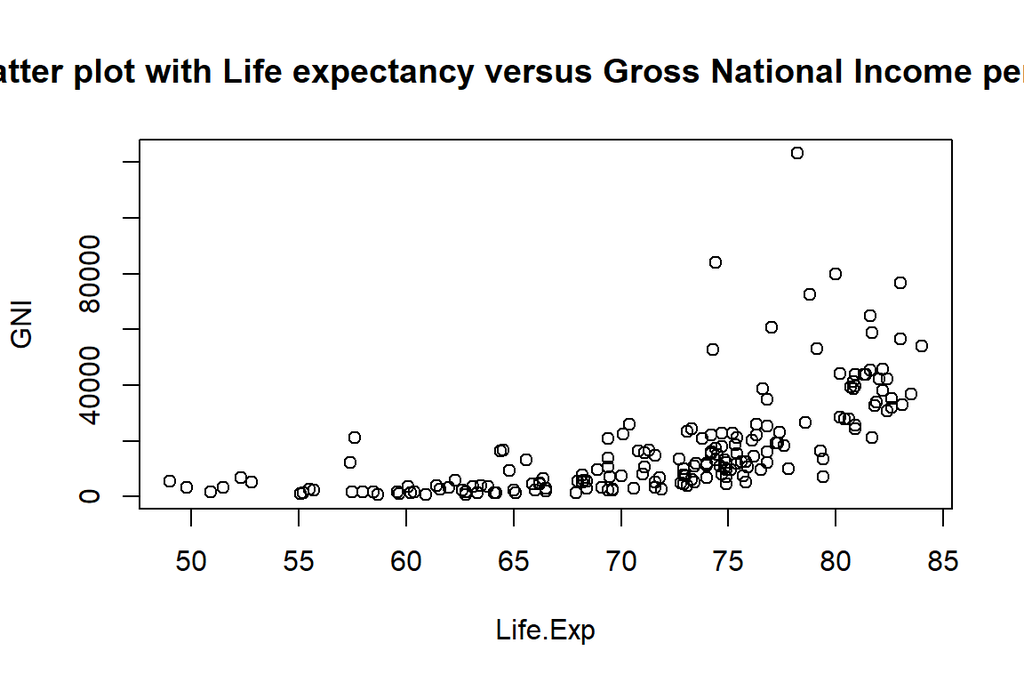

```r
plot(Life.Exp, GNI, main = title <- "Scatter plot with Life expectancy versus Gross National Income per capita")
```

```r
human_$HDIHIGHLOW <- ifelse(human_$HDI.Rank > 90,
c("high on list"), c("low on list"))
HDIHIGHLOW <- human_$HDIHIGHLOW
```

Here are some simple scatter plots of what I’m about to fit a linear regression line in. I’m using the wrangled data, called human_, where only variables of Human Development Index, Life expectancy at birth, Gross National Income per capita and Education expectancy are stored.

```r
lm(formula = Life.Exp ~ Edu.Exp)
```

```
##
## Call:
## lm(formula = Life.Exp ~ Edu.Exp)
##
## Coefficients:
## (Intercept)      Edu.Exp
##       40.98         2.34
```

```r
library(ggplot2)
```

```r
p1 <- ggplot(human_, aes(x = Life.Exp, y = Edu.Exp, col = HDI.Rank))
```

```r
p2 <- p1 + geom_point()
```

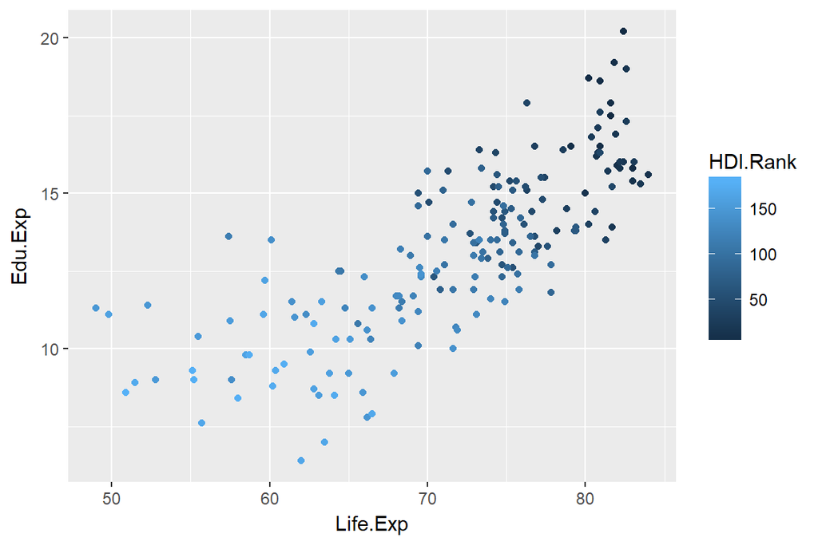

```r
p2
```

```r
p3 <- p2 + geom_smooth(method = "lm")
```

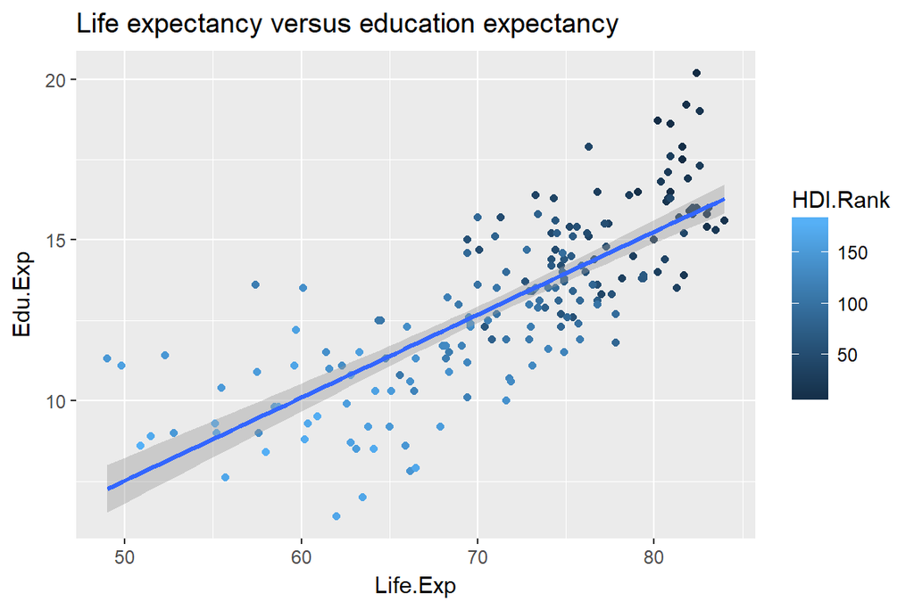

```r
p4 <- p3 + ggtitle("Life expectancy versus education expectancy")
p4
```

Here we can see a plot drawn on life expextancy versus education expectancy, where the coloring resembles HDI ranking: the darker a dot, the higher it falls on HDI Ranking. From this plot can be seen that there seems to be a nice correlation between expected years of education and life expectancy. A observation worth to notice is, that the correlation seems to get stronger in the countries with high HDI ranking, compared to the to counrties with low HDI ranking, where the countries fall a litte more scattered and further from the regression line.

```r
lm(formula = Life.Exp ~ GNI)
```

```
##
## Call:
## lm(formula = Life.Exp ~ GNI)
##
## Coefficients:
## (Intercept)          GNI
##   6.702e+01    2.622e-04
```

```r
LifeGNI1 <- ggplot(human_, aes(x = Life.Exp, y = GNI, col = HDI.Rank))
```

```r
LifeGNI2 <- LifeGNI1 + geom_point()
```

```r
LifeGNI3 <- LifeGNI2 + geom_smooth(method = "lm")
```

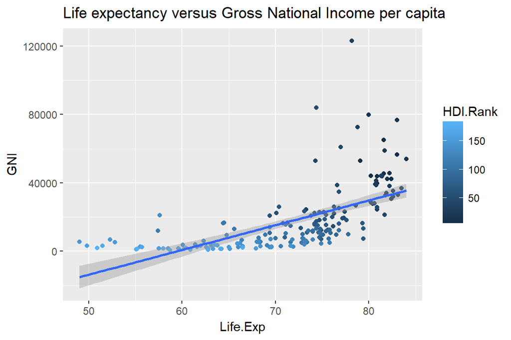

```r
LifeGNI4 <- LifeGNI3 + ggtitle("Life expectancy versus Gross National Income per capita")
LifeGNI4
```

This is a similar kind of linear regression drawn to visualize the effect of GNI to Life expectancy. Here can be seen that in the lower HDI rankings and GNI seems to fall pretty nicely on the regression line, but in the upper parts of HDI ranking list with high GNI, at somepoint the GNIs correlation to life expectancy weakens.

# Conclusion

The linear regression analysis done with the human data seems to support Wilkinsons and Pickets argument about economic growths importance to raising living standards: to some point the correlation is strong, but when reached a certain level, the effect of GNI looses its importance. The other variable of expected years of education there for seems to correlate with life expectancy even in countries with high HDI ranking. This makes me think about the controversy in western countries and their politics: what seems to be important is economic growth.